# Case Study 2: Bellabeat

### Analysis (Analyze)

#### Summarizing

I assessed the total number of participants in each data set.

```r
n_distinct(daily_activity$Id)
```

```
## [1] 33
```

```r
n_distinct(sleep_day$Id)
```

```
## [1] 24
```

```r
n_distinct(weight$Id)
```

```
## [1] 8
```

```r
n_distinct(HR$Id)
```

```
## [1] 14
```

```r
n_distinct(daily_intensities$Id)
```

```
## [1] 33
```

```r
n_distinct(daily_calories$Id)
```

```
## [1] 33
```

- Typically, 30 is the lowest number of participants needed to draw statistical significance from a study. As we can see, there are only 14 participants in the heart rate data set and 8 participants in the weight data set, so I will not be including them in my analysis.
- The daily activity, daily calories, and daily intensities day sets all included 33 participants and will be included. The sleep day data set only has 24 participants, but I have decided to include it as well because it is close to the cut-off. However, this is something to keep in mind when considering results of my analysis informed by the sleep day data set.

Next, I created some summary statistics for each data frame.

```r
# daily activity
daily_activity %>%
  select(TotalSteps,
         TotalDistance,
         SedentaryMinutes, Calories) %>%
  summary()
```

```
##    TotalSteps    TotalDistance    SedentaryMinutes    Calories
##  Min.   :    0   Min.   : 0.000   Min.   :   0.0   Min.   :   0
##  1st Qu.: 3790   1st Qu.: 2.620   1st Qu.: 729.8   1st Qu.:1828
##  Median : 7406   Median : 5.245   Median :1057.5   Median :2134
##  Mean   : 7638   Mean   : 5.490   Mean   : 991.2   Mean   :2304
##  3rd Qu.:10727   3rd Qu.: 7.713   3rd Qu.:1229.5   3rd Qu.:2793
##  Max.   :36019   Max.   :28.030   Max.   :1440.0   Max.   :4900
```

```r
# sleep_day
sleep_day %>%
  select(TotalSleepRecords, TotalMinutesAsleep, TotalTimeInBed) %>%
  summary()
```

```
##  TotalSleepRecords TotalMinutesAsleep TotalTimeInBed
##  Min.   :1.000     Min.   : 58.0      Min.   : 61.0
##  1st Qu.:1.000     1st Qu.:361.0      1st Qu.:403.0
##  Median :1.000     Median :433.0      Median :463.0
##  Mean   :1.119     Mean   :419.5      Mean   :458.6
##  3rd Qu.:1.000     3rd Qu.:490.0      3rd Qu.:526.0
##  Max.   :3.000     Max.   :796.0      Max.   :961.0
```

```r
# daily intensities
daily_intensities %>%
  select(VeryActiveMinutes, FairlyActiveMinutes, LightlyActiveMinutes, SedentaryMinutes) %>%
  summary()
```

```
##  VeryActiveMinutes FairlyActiveMinutes LightlyActiveMinutes SedentaryMinutes
##  Min.   :  0.00    Min.   :  0.00      Min.   :  0.0        Min.   :   0.0
##  1st Qu.:  0.00    1st Qu.:  0.00      1st Qu.:127.0        1st Qu.: 729.8
##  Median :  4.00    Median :  6.00      Median :199.0        Median :1057.5
##  Mean   : 21.16    Mean   : 13.56      Mean   :192.8        Mean   : 991.2
##  3rd Qu.: 32.00    3rd Qu.: 19.00      3rd Qu.:264.0        3rd Qu.:1229.5
##  Max.   :210.00    Max.   :143.00      Max.   :518.0        Max.   :1440.0
```

```r
# daily calories
daily_calories %>%
  select(Calories) %>%
  summary()
```

```
##     Calories
##  Min.   :   0
##  1st Qu.:1828
##  Median :2134
##  Mean   :2304
##  3rd Qu.:2793
##  Max.   :4900
```

#### Merging

I merged the daily_activity and sleep_day data sets to streamline the visualization process. Because sleep_day has less participants (24) than daily_activity (33), I used and verified an outer join. This way all participants from both daily_activity and sleep_day will be included.

```r
merged_activity_sleep <- merge(daily_activity,sleep_day, by="Id", all = TRUE)
  n_distinct(merged_activity_sleep$Id)
```

```
## [1] 33
```

### Visualization & Key Findings (Share)

#### Relationship Between Minutes Asleep & Time In Bed

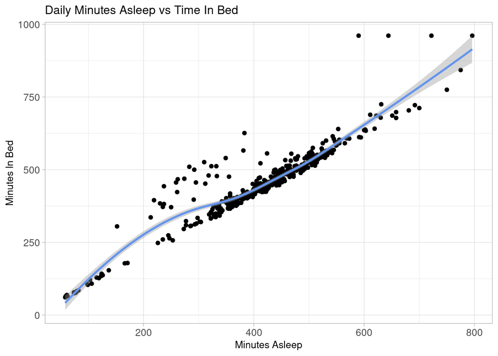

```r
ggplot(data=sleep_day,aes(x=TotalMinutesAsleep,y=TotalTimeInBed))+geom_point()+
  geom_smooth(method="loess",color="cornflowerblue")+
  theme_light()+
  labs(title= "Daily Minutes Asleep vs Time In Bed",
       x="Minutes Asleep",
       y="Minutes In Bed")+
  theme(plot.title = element_text(size=12),
        axis.title.x=element_text(size=10),
        axis.text.x=element_text(size=10),
        axis.title.y=element_text(size=10),
        axis.text.y=element_text(size=10))
```

Unsurprisingly, we see a nearly linear relationship between time in bed and time asleep.

#### Relationship Between Daily Steps & Daily Calories

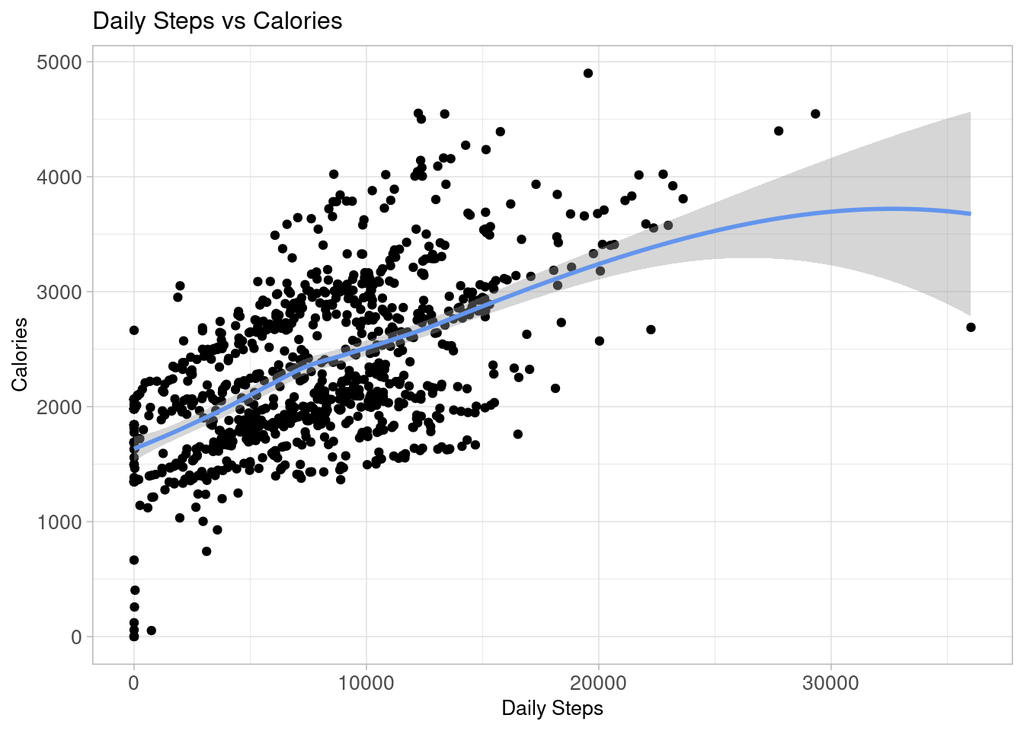

```r
ggplot(data=daily_activity,aes(x=TotalSteps,y=Calories))+geom_point()+
  geom_smooth(method="loess",color="cornflowerblue")+
  theme_light()+
  labs(title= "Daily Steps vs Calories",
       x="Daily Steps",
       y="Calories")+
  theme(plot.title = element_text(size=12),
        axis.title.x=element_text(size=10),
        axis.text.x=element_text(size=10),
        axis.title.y=element_text(size=10),
        axis.text.y=element_text(size=10))
```

#### Relationship Between Daily Steps & Sedentary Minutes

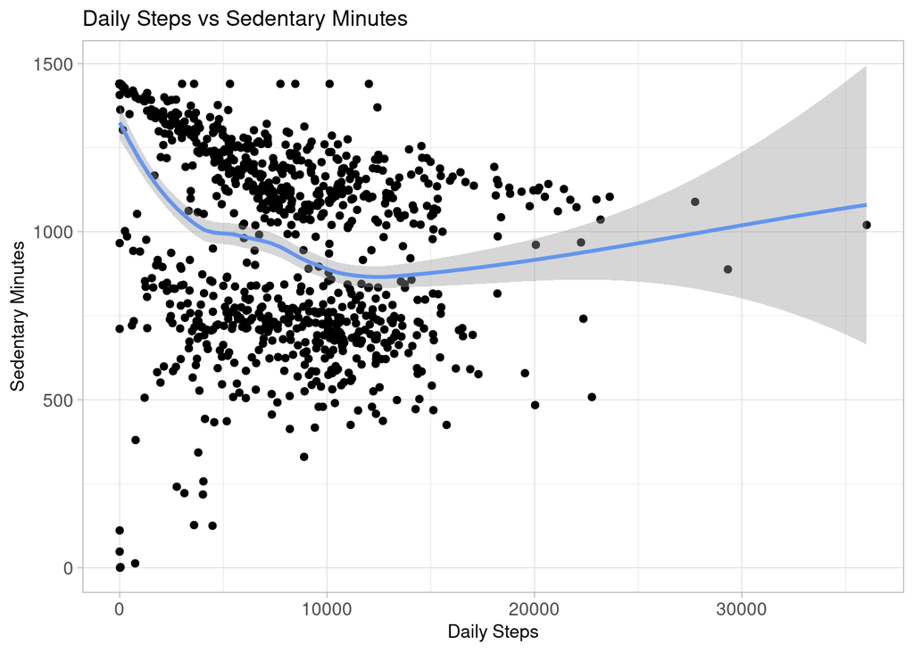

```r
ggplot(data=daily_activity,aes(x=TotalSteps,y=SedentaryMinutes))+geom_point()+
  geom_smooth(method="loess",color="cornflowerblue")+
  theme_light()+
  labs(title= "Daily Steps vs Sedentary Minutes",
       x="Daily Steps",
       y="Sedentary Minutes")+
  theme(plot.title = element_text(size=12),
        axis.title.x=element_text(size=10),
        axis.text.x=element_text(size=10),
        axis.title.y=element_text(size=10),
        axis.text.y=element_text(size=10))
```

We see a negative correlation between daily steps and sedentary minutes from 0 to about 15,000 steps, which is the range where the majority of data points occur. From 15,000 to 30,000 steps we see a slight positive correlation between fewer data points.

#### Activity Levels By Average Time Daily

```r
# calculate
  # avg intensity by day
  avg_daily_intensities <- daily_activity %>%
      group_by(date)%>%
      summarize(avg_very_active=mean(VeryActiveMinutes,na.rm=TRUE),
                avg_fairly_active=mean(FairlyActiveMinutes,na.rm=TRUE),
                avg_lightly_active=mean(LightlyActiveMinutes,na.rm=TRUE),
                avg_sedentary=mean(SedentaryMinutes,na.rm=TRUE)) %>%
      as.data.frame()
  # avg intensity daily
  n_distinct(daily_activity$date)
```

```
## [1] 31
```

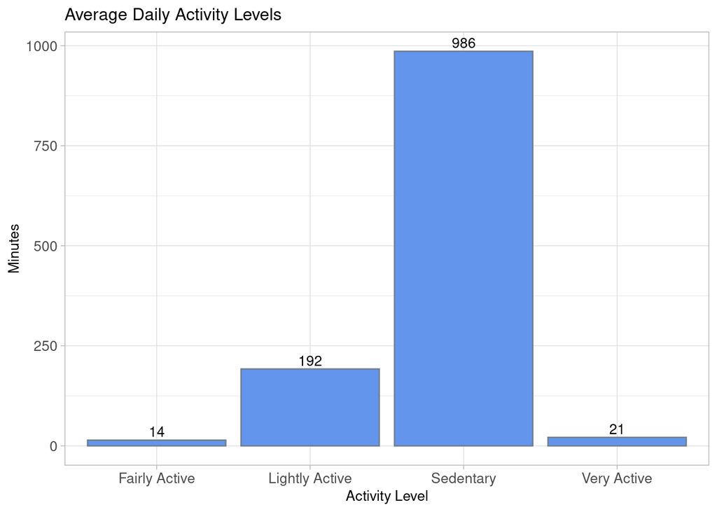

```r
  avg_intensities <- avg_daily_intensities %>%
      summarize(avg_very_active=mean(avg_very_active,na.rm=TRUE),
                avg_fairly_active=mean(avg_fairly_active,na.rm=TRUE),
                avg_lightly_active=mean(avg_lightly_active,na.rm=TRUE),
                avg_sedentary=mean(avg_sedentary,na.rm=TRUE)) %>%
      as.data.frame()

# transpose df
activity_level <- c("Very Active","Fairly Active","Lightly Active","Sedentary")
daily_average <- c(21,14,192,986)
final_avg_intensities <- data.frame(activity_level,daily_average)

# plot
ggplot(data=final_avg_intensities,aes(x=activity_level,y=daily_average))+geom_col(color="slategrey",fill="cornflowerblue")+
   theme_light()+
  labs(title="Average Daily Activity Levels",
       x="Activity Level",
       y="Minutes")+
  theme(plot.title = element_text(size=12),
        axis.title.x=element_text(size=10),
        axis.text.x=element_text(size=10),
        axis.title.y=element_text(size=10,),
        axis.text.y=element_text(size=10))+
  geom_text(aes(label = daily_average), vjust = -0.3, size=3.5)
```

We see that on average, the vast majority of participants’ time was spent sedentary (986 minutes or 16.4 hours per day), followed by lightly active (192 minutes or 3.2 hours), then very active (21 minutes), and finally fairly active (14 minutes).

#### Activity Levels By Percent

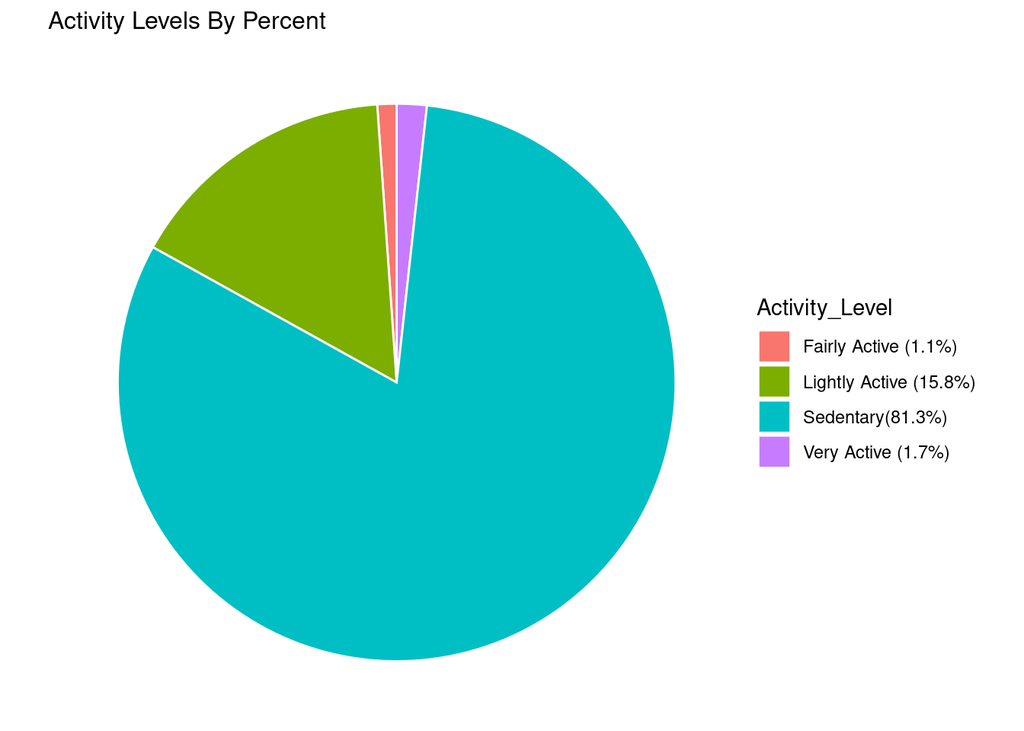

```r
# calculate
    intensity_sums <- daily_activity %>%
      summarize(very_active_sum = sum(VeryActiveMinutes,na.rm=TRUE),
                fairly_active_sum = sum(FairlyActiveMinutes,na.rm=TRUE),
                lightly_active_sum = sum(LightlyActiveMinutes,na.rm=TRUE),
                sedentary_sum = sum(SedentaryMinutes,na.rm=TRUE))

# df
  total <- c(19895,12751,181244,931738)
  Activity_Level <- c("Very Active (1.7%)", "Fairly Active (1.1%)", "Lightly Active (15.8%)", "Sedentary(81.3%)")
  intensities <- data.frame(Activity_Level, total)

# plot
  ggplot(intensities, aes(x="", y=total, fill=Activity_Level)) +
    geom_bar(stat="identity", width=1,color="white") +
    coord_polar("y", start=0)+
    theme_void()+
    labs(title="Activity Levels By Percent")+
    theme(plot.title = element_text(size=12, hjust=0))
```

Here we see those same activity levels represented as percentages. Again it is clear that the vast majority of participants’ time was spent sedentary (81.3%) rather than active (18.7% total).

#### Key Findings: Summary

All in all we discovered that time in bed was nearly linearly correlated to time asleep, daily steps were positively correlated with daily calories burned, daily steps and sedentary minutes were negatively correlated between 0 and 15,000 steps (the range the majority of users fell into), and that participants spent the majority of their time sedentary (81.3%) rather than active (18.7%).

### Conclusion

Thank you for your interest in my Bellabeat case study! Any comments or suggestions are welcome and appreciated. My name is Kirsten Goff and I can be contacted at kirstenagoff@gmail.com. Please feel free to connect with me on [**Linkedin**](https://www.linkedin.com/in/kirsten-goff-research/) and view more of my work in my [**Portfolio**](https://github.com/kirstengoff/kirstengoff.github.io).